# Projekt z przedmiotu Data Mining

Michał Błaszczykowski

## Cel projektu

Celem badania jest budowa optymalnego modelu klasyfikacyjnego za pomocą wybranych algorytmów uczenia maszynowego. Głównym zadaniem będzie zweryfikowanie na podstawie podanych predyktorów czy klient banku założy lokatę terminową.

## Opis zbioru badawczego

**Wszystkie informacje odnośnie wykorzystywanych zmiennych są przedstawione poniżej.**

**Zmienne:**

1. **age** (wiek klienta) – zmienna numeryczna
2. **job** (zawód klienta) – zmienna jakościowa, przyjmuje 12 poziomów:
1. admin (administrator)
2. technician (technik)
3. blue-collar (pracownik fizyczny)
4. hausemaid (pokojówka)
5. management (kierownik)
6. entrepreneur (przedsiębiorca)
7. services (usługi)
8. self-employed (samozatrudniony)
9. retired (emeryt)
10. student (student)
11. unemployed (bezrobotny)
12. unknown (nieznany)
3. **marital** (stan cywilny klienta) – zmienna jakościowa, przyjmuje 4 poziomy:
1. married (żonaty)
2. divorced (rozwiedziony, owdowiały)
3. single (wolny)
4. unknown (nieznany)
4. **education** (wykształcenie klienta) – zmienna jakościowa, przyjmuje 4 poziomy:
1. tertiary (wyższe)
2. secondary (średnie)
3. primary (podstawowe)
4. unknown (nieznany)
5. **default** (czy występuje niespłacony kredyt u klienta) – zmienna binarna, przyjmuje dwie wartości: yes, no.
6. **balance** (przeciętny stan konta klienta podany w euro) – zmienna numeryczna.
7. **housing** (czy występuje kredyt mieszkaniowy u klienta) – zmienna binarna, przyjmuje dwie wartości: yes, no.
8. **loan** (czy klient posiada zaciągniętą pożyczkę) – zmienna binarna, przyjmuje dwie wartości: yes, no.
9. **contact** (typ komunikacji banku z klientem) – zmienna jakościowa, przyjmuje 3 poziomy:
1. telephone (telefoniczna)
2. cellular (komórkowa)
3. unknown (nieznana)
10. **day** (numer dnia w miesiącu, w którym występował poprzedni kontakt banku z klientem) – zmienna numeryczna.
11. **month** (miesiąc, w którym występował poprzedni kontakt banku z klientem) - zmienna jakościowa, przyjmuje 12 poziomów.
12. **duration** (czas trwania ostatniego kontakt banku z klientem, podany w sekundach) – zmienna numeryczna.
- Jeżeli duration=0 (brak kontaktu), to y automatycznie przyjmuje „no”. Zatem takie obserwacje nie będą uwzględniane.
13. **campaign** (liczba kontaktów banku z klientem podczas obecnej kampanii marketingowej) – zmienna numeryczna.
14. **pdays** (liczba dni, które minęły od ostatniego kontaktu banku z klientem podczas trwania poprzedniej kampanii) – zmienna numeryczna
- -1 oznacza, że podczas poprzedniej kampanii bank nie kontaktował się z danym klientem.
15. **previous** (liczba kontaktów banku z klientem, które zostały wykonane przed obecną kampanią marketingową) – zmienna numeryczna.
16. **poutcome** (rezultat poprzedniej kampanii marketingowej – za sukces rozumiemy założenie lokaty) – zmienna jakościowa, przyjmuje 4 poziomy:
1. success (sukces)
2. failure (porażka)
3. other (inna)
4. unknown (nieznana)
17. **y** (informuje czy klient za sprawą obecnej kampanii marketingowej założył lokatę terminową w banku) – zmienna binarna, przyjmuje dwie wartości: yes, no. **Jest to zmienna zależna w naszym badaniu.**

**Podsumowanie zmiennych w zbiorze danych Bank Marketing**

```
##       age            job              marital           education
##  Min.   :19.00   Length:4521        Length:4521        Length:4521
##  1st Qu.:33.00   Class :character   Class :character   Class :character
##  Median :39.00   Mode  :character   Mode  :character   Mode  :character
##  Mean   :41.17
##  3rd Qu.:49.00
##  Max.   :87.00
##    default             balance        housing              loan
##  Length:4521        Min.   :-3313   Length:4521        Length:4521
##  Class :character   1st Qu.:   69   Class :character   Class :character
##  Mode  :character   Median :  444   Mode  :character   Mode  :character
##                     Mean   : 1423
##                     3rd Qu.: 1480
##                     Max.   :71188
##    contact               day           month              duration
##  Length:4521        Min.   : 1.00   Length:4521        Min.   :   4
##  Class :character   1st Qu.: 9.00   Class :character   1st Qu.: 104
##  Mode  :character   Median :16.00   Mode  :character   Median : 185
##                     Mean   :15.92                      Mean   : 264
##                     3rd Qu.:21.00                      3rd Qu.: 329
##                     Max.   :31.00                      Max.   :3025
##     campaign          pdays           previous         poutcome
##  Min.   : 1.000   Min.   : -1.00   Min.   : 0.0000   Length:4521
##  1st Qu.: 1.000   1st Qu.: -1.00   1st Qu.: 0.0000   Class :character
##  Median : 2.000   Median : -1.00   Median : 0.0000   Mode  :character
##  Mean   : 2.794   Mean   : 39.77   Mean   : 0.5426
##  3rd Qu.: 3.000   3rd Qu.: -1.00   3rd Qu.: 0.0000
##  Max.   :50.000   Max.   :871.00   Max.   :25.0000
##       y
##  Length:4521
##  Class :character
##  Mode  :character
##
##
##
```

## Analiza zbioru badawczego oraz przygotowanie danych

Zbiór danych **Bank Marketing** nie posiada braków danych. Dodatkowo nie występują obserwacje, gdzie zmienna `duration` przyjmuje wartość 0. W przypadku występowania takich obserwacji należałoby je usunąć. Posiadamy zatem kompletny zbiór danych do rozpoczęcia badań.

Sprawdzimy teraz czy w naszym zbiorze danych nie występują zmienne stałe oraz czy nie będzie konieczna standaryzacja zmiennych numerycznych w celu uzyskania optymalnych modeli klasyfikacyjnych.

W celu dokładnego uporządkowania zbioru danych wykorzystamy funkcję `preProcess` pakietu `caret`. Sprawdzi ona, które z naszych zmiennych należałoby standaryzować, usunać (zmienne stałe) lub dokonać normalizacji rozkładu (transformacja YeoJohnsona).

**Otrzymujemy następujące wyniki:**

1. Standaryzować należy zmienne: `age`, `balance`, `day`, `duration`, `campaign`, `previous`.
2. Transformacja `YeoJohnsona` zostanie przeprowadzona dla zmiennych: `age`, `balance`, `day`, `duration`, `campaign`.
3. Zmienne stałe to: `pdays` (tutaj przeważa wartość -1, czyli bank nie kontaktował się z klientem podczas ostatniej kampanii marketingowej).

Oto kilka wierszy naszego zbioru danych po przeprowadzeniu wspomnianych operacji.

```
##          age         job marital education default     balance housing loan
## 1 -1.1405573  unemployed married   primary      no  0.28218551      no   no
## 2 -0.7437275    services married secondary      no  1.20969808     yes  yes
## 3 -0.5022043  management  single  tertiary      no  0.13042255     yes   no
## 4 -1.1405573  management married  tertiary      no  0.17492414     yes  yes
## 5  1.5260765 blue-collar married secondary      no -0.44532036     yes   no
## 6 -0.5022043  management  single  tertiary      no -0.09402476      no   no
##    contact         day month    duration  campaign   previous poutcome  y
## 1 cellular  0.43269740   oct -0.88801220 -1.114367 -0.3203774  unknown no
## 2 cellular -0.52525171   may  0.16694826 -1.114367  2.0415079  failure no
## 3 cellular  0.09009028   apr -0.02302672 -1.114367  0.2700939  failure no
## 4  unknown -1.72149146   jun  0.05636401  1.077732 -0.3203774  unknown no
## 5  unknown -1.38226854   may  0.19688638 -1.114367 -0.3203774  unknown no
## 6 cellular  0.86636855   feb -0.31118454  0.122366  1.4510366  failure no
```

**Dzielimy teraz zbiór danych na zbiór uczący i zbiór treningowy.**

W zbiorze uczącym znajdzie się 2/3 wszystkich obserwacji, natomiast w zbiorze testowym 1/3 wszystkich obserwacji.

Wartości przyjmowane przez zmienną wynikową pozostaną mniej więcej w takiej samej proporcji w zbiorze uczącym i zbiorze testowym. Zatem około 11% wartości zmiennej wynikowej `y` będzie przyjmowało wartość `yes`.

**Przeprowadzimy również kroswalidację na zbiorze uczącym (kroswalidacja 10-krotna).**

## Metody wykorzystywane w projekcie

**Metody:**

- **Proste drzewo decyzyjne typu CART**
- **Drzewo decyzyjne Ctree**
- **Las losowy**
- **Boosting**
- **LDA**
- **Regresja logistyczna**
- **Metoda k najbliższych sąsiadów**
- **Naiwny klasyfikator Bayesa**

**Dokładność klasyfikacji każdej z metod zostanie sprawdzona zarówno dla ustawionych parametrów domyślnych jak również tych wybranych niezależnie przez autora projektu.**

**Na końcu pracy wszystkie wykorzystane metody zostaną porównane ze względu na uzyskaną skuteczność klasyfikacyjną.**

### Proste drzewo decyzyjne typu CART

**Drzewo decyzyjne** jest strukturą hierarchiczną przedstawiającą model klasyfikacyjny lub regresyjny. Drzewa decyzyjne stosowane są przede wszystkim, gdy funkcyjna postać związku pomiędzy predyktorami a zmienną wynikową jest nieznana lub ciężka do ustalenia.

Każde drzewo decyzyjne składa się z **korzenia (ang. root)**, **węzłów (ang. nodes)** i **liści (ang. leaves)**. Korzeniem nazywamy początkowy węzeł drzewa, z którego poprzez **podziały (ang. splits)** powstają kolejne węzły potomne. Końcowe węzły, które nie podlegają podziałom nazywamy liśćmi, a linie łączące węzły nazywamy **gałęziami (ang. branches)**.

Jeśli drzewo służy do zadań klasyfikacyjnych, to liście zawierają informację o tym, która klasa w danym ciągu podziałów jest najbardziej prawdopodobna. Natomiast, jeśli drzewo jest regresyjne, to liście zawierają warunkowe miary tendencji centralnej (najczęściej średnią) wartości zmiennej wynikowej. **Warunek stanowi szereg podziałów doprowadzający do danego węzła terminalnego (liścia)**. Drzewo “dąży” do takiego podziału by kolejne węzły, a co za tym idzie również liście, były jak najbardziej jednorodne ze względu na zmienną wynikową.

Budując drzewo decyzyjne ustawiamy `tuneLength = 10`. Pozwoli to na wyświetlenie 10 propozycji różnych drzew o podanym parametrze `cp` (określa złożoność drzewa) oraz miarach dopasowania modelu (`Accuracy` i `Kappa`).

```
## CART
##
## 3015 samples
##   15 predictor
##    2 classes: 'no', 'yes'
##
## No pre-processing
## Resampling: Cross-Validated (10 fold)
## Summary of sample sizes: 2714, 2713, 2713, 2713, 2714, 2715, ...
## Resampling results across tuning parameters:
##
##   cp           Accuracy   Kappa
##   0.003831418  0.8849033  0.3435325
##   0.004022989  0.8845721  0.3387744
##   0.004310345  0.8845721  0.3387744
##   0.004789272  0.8849044  0.3377150
##   0.005747126  0.8865622  0.3267770
##   0.008620690  0.8905390  0.3242292
##   0.011494253  0.8908558  0.3137976
##   0.013409962  0.8921814  0.3200373
##   0.025862069  0.8928491  0.3375976
##   0.044061303  0.8845688  0.1475487
##
## Accuracy was used to select the optimal model using the largest value.
## The final value used for the model was cp = 0.02586207.
```

**Wybieramy sugerowany model i rysujemy odpowiadające mu drzewo.**

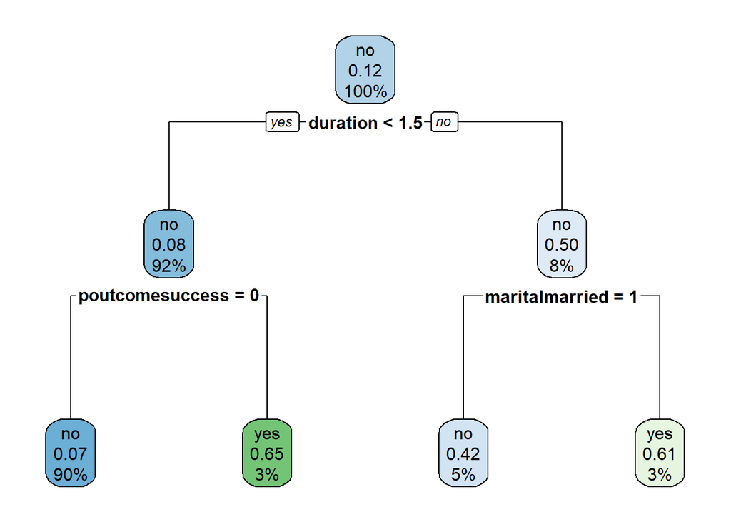

**Otrzymujemy dosyć prosty model o wysokiej skuteczności (klasyfikacja na zbiorze uczącym)**

Wybierzemy teraz kilka innych wartości `cp` i sprawdzimy jak wpłynie to na klasyfikacje.

```
## CART
##
## 3015 samples
##   15 predictor
##    2 classes: 'no', 'yes'
##
## No pre-processing
## Resampling: Cross-Validated (10 fold)
## Summary of sample sizes: 2713, 2713, 2715, 2713, 2713, 2713, ...
## Resampling results across tuning parameters:
##
##   cp           Accuracy   Kappa
##   0.000100000  0.8825755  0.3528323
##   0.003422222  0.8872245  0.3349997
##   0.006744444  0.8935269  0.3414783
##   0.010066667  0.8931946  0.3418166
##   0.013388889  0.8941891  0.3486922
##   0.016711111  0.8948536  0.3453482
##   0.020033333  0.8955158  0.3500005
##   0.023355556  0.8931913  0.3500942
##   0.026677778  0.8935247  0.3504162
##   0.030000000  0.8935247  0.3525041
##
## Accuracy was used to select the optimal model using the largest value.
## The final value used for the model was cp = 0.02003333.
```

Wraz ze wzrostem złożoności naszego drzewa decyzyjnego nie występuje znacząca poprawa w klasyfikacji.

**Dokonamy teraz predykcji dla obu model na zbiorze testowym i ocenimy ich faktyczną skuteczność.**

**Predykcja dla modelu o domyślnych współczynnikach z `cp = 0.02586207`.**

```
## Confusion Matrix and Statistics
##
##           Reference
## Prediction   no  yes
##        no  1301  114
##        yes   32   59
##
##                Accuracy : 0.9031
##                  95% CI : (0.887, 0.9175)
##     No Information Rate : 0.8851
##     P-Value [Acc > NIR] : 0.01456
##
##                   Kappa : 0.3994
##
##  Mcnemar's Test P-Value : 2.033e-11
##
##             Sensitivity : 0.34104
##             Specificity : 0.97599
##          Pos Pred Value : 0.64835
##          Neg Pred Value : 0.91943
##              Prevalence : 0.11487
##          Detection Rate : 0.03918
##    Detection Prevalence : 0.06042
##       Balanced Accuracy : 0.65852
##
##        'Positive' Class : yes
##
```

Skuteczność modelu na zbiorze testowym okazuje się jeszcze lepsza niż na zbiorze uczącym. Poprawnie zostaje zaklasyfikowane około 90% wszystkich obserwacji.

```
## Confusion Matrix and Statistics
##
##           Reference
## Prediction   no  yes
##        no  1305  116
##        yes   28   57
##
##                Accuracy : 0.9044
##                  95% CI : (0.8884, 0.9188)
##     No Information Rate : 0.8851
##     P-Value [Acc > NIR] : 0.009343
##
##                   Kappa : 0.3962
##
##  Mcnemar's Test P-Value : 4.168e-13
##
##             Sensitivity : 0.32948
##             Specificity : 0.97899
##          Pos Pred Value : 0.67059
##          Neg Pred Value : 0.91837
##              Prevalence : 0.11487
##          Detection Rate : 0.03785
##    Detection Prevalence : 0.05644
##       Balanced Accuracy : 0.65424
##
##        'Positive' Class : yes
##
```

**Wyniki są niemal identyczne. Dla obu model otrzymujemy skuteczność w przybliżeniu na poziomie 90%.**

**Jakość predykcji na podstawie drzewa decyzyjnego CART okazała się bardzo dobra.**

### Drzewo Ctree

Wykorzystamy teraz inny algorytm budowy drzewa decyzyjnego, mianowicie **Ctree**.

Główną różnicą w stosunku do drzew typu **CART** jest sposób budowy podziałów, oparty na teście niezależności $\chi^2$ Pearsona. Wyboru reguły podziału dokonuje się poprzez testowanie niezależności zmiennej niezależnej z predyktorami. Reguła o największej wartości statystyki $\chi^2$ jest stosowana w pierwszej kolejności.

```
## Conditional Inference Tree
##
## 3015 samples
##   15 predictor
##    2 classes: 'no', 'yes'
##
## No pre-processing
## Resampling: Cross-Validated (10 fold)
## Summary of sample sizes: 2714, 2713, 2713, 2713, 2714, 2715, ...
## Resampling results across tuning parameters:
##
##   mincriterion  Accuracy   Kappa
##   0.0100000     0.8819099  0.3371806
##   0.1188889     0.8862189  0.3353055
##   0.2277778     0.8845556  0.3379204
##   0.3366667     0.8862200  0.3485749
##   0.4455556     0.8885379  0.3603673
##   0.5544444     0.8888668  0.3397295
##   0.6633333     0.8882068  0.3447169
##   0.7722222     0.8868724  0.3159073
##   0.8811111     0.8862101  0.3286595
##   0.9900000     0.8875390  0.3086971
##
## Accuracy was used to select the optimal model using the largest value.
## The final value used for the model was mincriterion = 0.5544444.
```

Domyślnym parametrem jest `mincriterion`. Najprościej mówiąc jeżeli `mincriterion = 0.99`, to `p.value - p` musi być mniejsze od `0.01`(test $\chi^2$ Pearsona), aby podzielić węzeł nadrzędny na kolejne węzły podrzędne. Im większa wartość parametru, tym trudniej jest rodzielać drzewo decyzyjne na kolejne węzły.

Wybieramy optymalny model dla `mincriterion = 0.5544444`. Rysowanie tego drzewa nie ma sensu, ponieważ jest to bardzo złożony model przez co staje się mało czytelny.

Wykorzystamy `mincriterion = 0.99999999`, podczas budowy nowego modelu. Pozwoli to jak najlepiej zobrazować nasze drzewo decyzyjne.

```
## Conditional Inference Tree
##
## 3015 samples
##   15 predictor
##    2 classes: 'no', 'yes'
##
## No pre-processing
## Resampling: Cross-Validated (10 fold)
## Summary of sample sizes: 2714, 2713, 2713, 2713, 2714, 2715, ...
## Resampling results:
##
##   Accuracy   Kappa
##   0.8882079  0.2630676
##
## Tuning parameter 'mincriterion' was held constant at a value of 1
```

Pomimo bardzo dużej różnicy w wartości parametru, to otrzymujemy praktycznie identyczną skuteczność na zbiorze uczącym.

Poniżej przedstawiony jest rysunek prostszego drzewa.

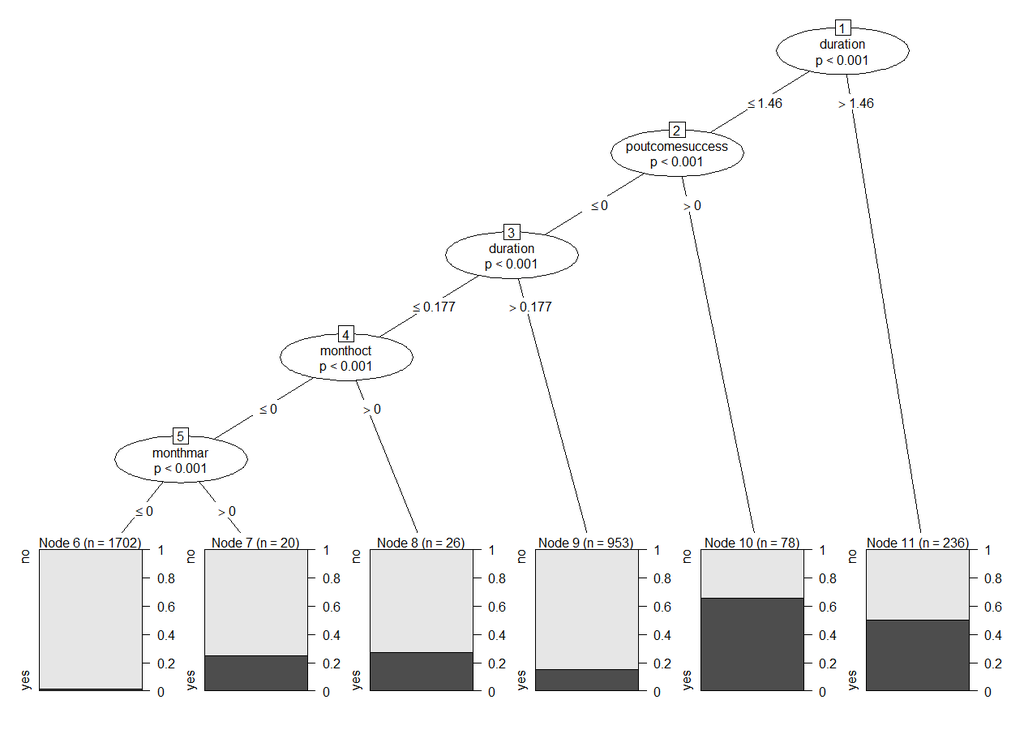

**Testujemy teraz wyniki predykcji na zbiorze testowym odpowiednio 1 i 2 modelu.**

```
## Confusion Matrix and Statistics
##
##           Reference
## Prediction   no  yes
##        no  1294  104
##        yes   39   69
##
##                Accuracy : 0.905
##                  95% CI : (0.8891, 0.9194)
##     No Information Rate : 0.8851
##     P-Value [Acc > NIR] : 0.007406
##
##                   Kappa : 0.4418
##
##  Mcnemar's Test P-Value : 8.701e-08
##
##             Sensitivity : 0.39884
##             Specificity : 0.97074
##          Pos Pred Value : 0.63889
##          Neg Pred Value : 0.92561
##              Prevalence : 0.11487
##          Detection Rate : 0.04582
##    Detection Prevalence : 0.07171
##       Balanced Accuracy : 0.68479
##
##        'Positive' Class : yes
##
```

```
## Confusion Matrix and Statistics
##
##           Reference
## Prediction   no  yes
##        no  1321  148
##        yes   12   25
##
##                Accuracy : 0.8938
##                  95% CI : (0.8771, 0.9089)
##     No Information Rate : 0.8851
##     P-Value [Acc > NIR] : 0.1561
##
##                   Kappa : 0.206
##
##  Mcnemar's Test P-Value : <2e-16
##
##             Sensitivity : 0.14451
##             Specificity : 0.99100
##          Pos Pred Value : 0.67568
##          Neg Pred Value : 0.89925
##              Prevalence : 0.11487
##          Detection Rate : 0.01660
##    Detection Prevalence : 0.02457
##       Balanced Accuracy : 0.56775
##
##        'Positive' Class : yes
##
```

## Las losowy

Jeżeli pojedyńcze drzewo decyzyjne charakteryzuje się dużą wariancją i nie daje oczekiwanych rezultatów, to można wykorzystać zbiór takich drzew połączonych w pewien sposób. Tak powstały metody: **random forest**,**bagging**,**boosting**.

**Metoda lasów losowych (random forest)** polega na losowaniu dla każdego drzewa wchodzącego w skład lasu **m** predyktorów spośród **p** dostępnych, a następnie budowaniu drzew z wykorzystaniem tylko tych predyktorów. Dzięki temu za każdym razem drzewo jest konstruuowane w oparciu o nowy zestaw cech. Otrzymane predykcje nie są wtedy, aż tak skorelowane. Pozwala to na uzyskanie większej liczby informacji, co przekłada się na lepsze wyniki końcowego modelu.

```
## Random Forest
##
## 3015 samples
##   15 predictor
##    2 classes: 'no', 'yes'
##
## No pre-processing
## Resampling: Cross-Validated (10 fold)
## Summary of sample sizes: 2714, 2713, 2713, 2713, 2714, 2715, ...
## Resampling results across tuning parameters:
##
##   mtry  Accuracy   Kappa
##    2    0.8849110  0.02204114
##    6    0.8958502  0.29239105
##   10    0.8968425  0.34563883
##   15    0.8971791  0.37597794
##   19    0.8971703  0.38611671
##   23    0.8988282  0.39995714
##   28    0.8955125  0.39893524
##   32    0.8971648  0.40163725
##   36    0.8955092  0.39747104
##   41    0.8961737  0.40377134
##
## Accuracy was used to select the optimal model using the largest value.
## The final value used for the model was mtry = 23.
```

Otrzymujemy optymalne rozwiązanie dla **23** predyktorów. **Jeżeli zmienna jest typu jakościowego, to każdy poziom takiej zmiennej jest traktowany jako predyktor.** Możemy zauważyć, że różnica pomiędzy`Accuracy` w drzewach wykorzystujących 6 zmiennych i 41 zmiennych jest bardzo mała, dlatego nie będziemy budowali drugiego modelu. Poniżej znajduje się podsumowanie naszego wybranego modelu.

```
##
## Call:
##  randomForest(x = x, y = y, mtry = min(param$mtry, ncol(x)))
##                Type of random forest: classification
##                      Number of trees: 500
## No. of variables tried at each split: 23
##
##         OOB estimate of  error rate: 10.45%
## Confusion matrix:
##       no yes class.error
## no  2576  91  0.03412073
## yes  224 124  0.64367816
```

**Sprawdzamy skuteczność modelu na zbiorze testowym.**

```
## Confusion Matrix and Statistics
##
##           Reference
## Prediction   no  yes
##        no  1285  101
##        yes   48   72
##
##                Accuracy : 0.9011
##                  95% CI : (0.8849, 0.9157)
##     No Information Rate : 0.8851
##     P-Value [Acc > NIR] : 0.02692
##
##                   Kappa : 0.4386
##
##  Mcnemar's Test P-Value : 2.044e-05
##
##             Sensitivity : 0.41618
##             Specificity : 0.96399
##          Pos Pred Value : 0.60000
##          Neg Pred Value : 0.92713
##              Prevalence : 0.11487
##          Detection Rate : 0.04781
##    Detection Prevalence : 0.07968
##       Balanced Accuracy : 0.69009
##
##        'Positive' Class : yes
##
```

**Otrzymujemy kolejny raz skuteczność predykcji na poziomie `90%`.**

## Boosting

W metodzie **Boosting** nie wykorzystujemy za każdym razem tych samych predyktorów do budowy drzewa. **Nie stosuje się tu również prób bootstrapowych**. Algorytm prezentuje się następująco: 1 drzewo uczy się zmienności zmiennej wyjściowej **y**, kolejne drzewo uczy się zmienności **y-r**, gdzie **r** jest to zbiór informacji uzyskanych w 1 kroku. Postępowanie powtarza się do momentu wyczerpania liczby drzew w modelu.

```
## Stochastic Gradient Boosting
##
## 3015 samples
##   15 predictor
##    2 classes: 'no', 'yes'
##
## No pre-processing
## Resampling: Cross-Validated (10 fold)
## Summary of sample sizes: 2714, 2713, 2713, 2713, 2714, 2715, ...
## Resampling results across tuning parameters:
##
##   interaction.depth  n.trees  Accuracy   Kappa
##   1                   50      0.8938624  0.2503113
##   1                  100      0.8985092  0.3522350
##   1                  150      0.8985092  0.3612268
##   1                  200      0.8985048  0.3759833
##   1                  250      0.8981714  0.3755851
##   2                   50      0.8981769  0.3481082
##   2                  100      0.8995070  0.3809543
##   2                  150      0.8981825  0.3825880
##   2                  200      0.8958613  0.3781039
##   2                  250      0.8935379  0.3596505
##   3                   50      0.9004970  0.3782908
##   3                  100      0.9001637  0.3967269
##   3                  150      0.8978392  0.3981496
##   3                  200      0.8978414  0.3979939
##   3                  250      0.8968447  0.3869802
##   4                   50      0.8948624  0.3464487
##   4                  100      0.8928646  0.3555703
##   4                  150      0.8928657  0.3648211
##   4                  200      0.8905423  0.3640680
##   4                  250      0.8915313  0.3692864
##   5                   50      0.8945258  0.3625465
##   5                  100      0.8905390  0.3628045
##   5                  150      0.8918691  0.3775665
##   5                  200      0.8882355  0.3660753
##   5                  250      0.8902123  0.3825200
##
## Tuning parameter 'shrinkage' was held constant at a value of 0.1
##
## Tuning parameter 'n.minobsinnode' was held constant at a value of 10
## Accuracy was used to select the optimal model using the largest value.
## The final values used for the model were n.trees = 50, interaction.depth =
##  3, shrinkage = 0.1 and n.minobsinnode = 10.
```

Otrzmujemy finalny model z około `90%` skutecznością na zbiorze uczącym.

Podane zostaną teraz inne parametry: `n.trees = c(500,1000)`, `interaction.depth = 2:6`, `shrinkage = 0.05`, `n.minobsinnode = 25`.

`n.trees` to liczba wykorzystwanych drzew w modelu

`interaction.depth` to maksymalna głębokość drzew

`shrinkage` - to szybkość uczenia

`n.minobsinnode` - to minimalna liczba obserwacji w węźle

```
## Stochastic Gradient Boosting
##
## 3015 samples
##   15 predictor
##    2 classes: 'no', 'yes'
##
## No pre-processing
## Resampling: Cross-Validated (10 fold)
## Summary of sample sizes: 2713, 2713, 2713, 2714, 2713, 2713, ...
## Resampling results across tuning parameters:
##
##   interaction.depth  n.trees  Accuracy   Kappa
##   2                   500     0.8941904  0.3572407
##   2                  1000     0.8951904  0.3744203
##   3                   500     0.8922037  0.3605198
##   3                  1000     0.8912114  0.3686511
##   4                   500     0.8922070  0.3688539
##   4                  1000     0.8908781  0.3782900
##   5                   500     0.8902125  0.3561666
##   5                  1000     0.8875646  0.3523342
##   6                   500     0.8918715  0.3734787
##   6                  1000     0.8888891  0.3571765
##
## Tuning parameter 'shrinkage' was held constant at a value of 0.05
##
## Tuning parameter 'n.minobsinnode' was held constant at a value of 25
## Accuracy was used to select the optimal model using the largest value.
## The final values used for the model were n.trees = 1000, interaction.depth =
##  2, shrinkage = 0.05 and n.minobsinnode = 25.
```

Pomimo wykorzystania większej liczby drzew nie otrzymujemy poprawy w jakości modelu. Dokładność predykcji na zbiorze uczącym jest minimalnie mniejsza. Dokonujemy zatem predykcji na zbiorze testowym wykorzystując zbudowane modele.

**Model z wartościami domyślnymi**

```
## Confusion Matrix and Statistics
##
##           Reference
## Prediction   no  yes
##        no  1300  117
##        yes   33   56
##
##                Accuracy : 0.9004
##                  95% CI : (0.8842, 0.9151)
##     No Information Rate : 0.8851
##     P-Value [Acc > NIR] : 0.03259
##
##                   Kappa : 0.379
##
##  Mcnemar's Test P-Value : 1.228e-11
##
##             Sensitivity : 0.32370
##             Specificity : 0.97524
##          Pos Pred Value : 0.62921
##          Neg Pred Value : 0.91743
##              Prevalence : 0.11487
##          Detection Rate : 0.03718
##    Detection Prevalence : 0.05910
##       Balanced Accuracy : 0.64947
##
##        'Positive' Class : yes
##
```

Dokładność wynosi około `90%`.

**Model z ustawionymi parametrami.**

```
## Confusion Matrix and Statistics
##
##           Reference
## Prediction   no  yes
##        no  1289  107
##        yes   44   66
##
##                Accuracy : 0.8997
##                  95% CI : (0.8834, 0.9144)
##     No Information Rate : 0.8851
##     P-Value [Acc > NIR] : 0.03921
##
##                   Kappa : 0.4141
##
##  Mcnemar's Test P-Value : 4.524e-07
##
##             Sensitivity : 0.38150
##             Specificity : 0.96699
##          Pos Pred Value : 0.60000
##          Neg Pred Value : 0.92335
##              Prevalence : 0.11487
##          Detection Rate : 0.04382
##    Detection Prevalence : 0.07304
##       Balanced Accuracy : 0.67425
##
##        'Positive' Class : yes
##
```

Wynik jest minimalnie gorszy, jednak w przybliżeniu to dalej `90%`.

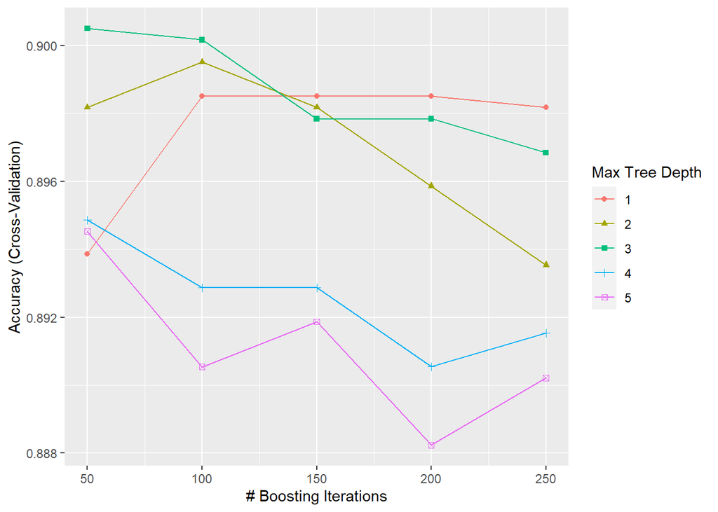

**Różnice są bardzo małe, zatem należałoby wybrać najmniej rozbudowany model.**

## Model LDA - analiza dyskryminacji liniowej

**Liniowa analiza dyskryminacyjna** i związany z nią liniowy **dyskryminator Fishera** są używanie w uczeniu maszynowym do znalezienia liniowej kombinacji cech, które najlepiej rozróżniają dwie lub więcej klas obiektów lub zdarzeń. Wynikowe kombinacje są używane jako klasyfikator liniowy lub służą redukcji wymiarów do późniejszej klasyfikacji statystycznej.

Budujemy model LDA. W tej metodzie nie występują parametry domyślne.

```
## Linear Discriminant Analysis
##
## 3015 samples
##   15 predictor
##    2 classes: 'no', 'yes'
##
## No pre-processing
## Resampling: Cross-Validated (10 fold)
## Summary of sample sizes: 2714, 2713, 2713, 2713, 2714, 2715, ...
## Resampling results:
##
##   Accuracy   Kappa
##   0.8948436  0.3502297
```

**Na zbiorze uczącym `Accuracy` wynosi w przybliżeniu `89%`. Przechodzimy do predykcji na zbiorze testowym.**

```
## Confusion Matrix and Statistics
##
##           Reference
## Prediction   no  yes
##        no  1300  120
##        yes   33   53
##
##                Accuracy : 0.8984
##                  95% CI : (0.882, 0.9132)
##     No Information Rate : 0.8851
##     P-Value [Acc > NIR] : 0.05566
##
##                   Kappa : 0.3605
##
##  Mcnemar's Test P-Value : 3.584e-12
##
##             Sensitivity : 0.30636
##             Specificity : 0.97524
##          Pos Pred Value : 0.61628
##          Neg Pred Value : 0.91549
##              Prevalence : 0.11487
##          Detection Rate : 0.03519
##    Detection Prevalence : 0.05710
##       Balanced Accuracy : 0.64080
##
##        'Positive' Class : yes
##
```

**Na zbiorze testowym otrzymujemy nieco lepsze reultaty, mianowicie skuteczność na poziomie 90%.**

## Regresja Logistyczna

**Regresja logistyczna** jest techniką z rodziny klasyfikatorów liniowych z reprezentacją logistyczną, a formalnie należy do rodziny uogólnionych modeli liniowych **(GLM)**. Stosowana jest wówczas, gdy zmienna wynikowa posiada dwa stany (sukces i porażka), kodowane najczęściej za pomocą 1 i 0. W tej metodzie modelowane jest warunkowe prawdopodobieństwo sukcesu za pomocą kombinacji liniowej predyktorów X.

```
## Generalized Linear Model
##
## 1506 samples
##   15 predictor
##    2 classes: 'no', 'yes'
##
## No pre-processing
## Resampling: Cross-Validated (10 fold)
## Summary of sample sizes: 1355, 1355, 1355, 1356, 1355, 1355, ...
## Resampling results:
##
##   Accuracy   Kappa
##   0.9023797  0.3989509
```

```
##
## Call:
## NULL
##
## Deviance Residuals:
##     Min       1Q   Median       3Q      Max
## -2.3372  -0.3562  -0.1811  -0.0728   3.6566
##
## Coefficients:
##                    Estimate Std. Error z value Pr(>|z|)
## (Intercept)        -2.06545    0.73276  -2.819  0.00482 **
## age                 0.20313    0.13832   1.469  0.14194
## `jobblue-collar`   -0.56284    0.44920  -1.253  0.21021
## jobentrepreneur    -0.38554    0.68669  -0.561  0.57450
## jobhousemaid       -1.13365    0.88636  -1.279  0.20090
## jobmanagement       0.04421    0.46861   0.094  0.92484
## jobretired          0.39386    0.54640   0.721  0.47102
## `jobself-employed` -0.97327    0.68100  -1.429  0.15295
## jobservices        -0.13213    0.51639  -0.256  0.79805
## jobstudent         -0.15636    0.77405  -0.202  0.83991
## jobtechnician      -0.18553    0.41635  -0.446  0.65587
## jobunemployed      -3.23460    1.36884  -2.363  0.01813 *
## jobunknown          0.89255    1.13663   0.785  0.43230
## maritalmarried     -0.59785    0.30560  -1.956  0.05043 .
## maritalsingle      -0.14361    0.36915  -0.389  0.69726
## educationsecondary  0.15932    0.37615   0.424  0.67190
## educationtertiary   0.36378    0.43878   0.829  0.40707
## educationunknown   -1.23969    0.81872  -1.514  0.12998
## defaultyes          0.66995    0.70129   0.955  0.33942
## balance            -0.07912    0.11468  -0.690  0.49028
## housingyes         -0.19695    0.25313  -0.778  0.43654
## loanyes            -0.52259    0.34323  -1.523  0.12786
## contacttelephone   -0.12885    0.44976  -0.286  0.77450
## contactunknown     -1.84489    0.43786  -4.213 2.52e-05 ***
## day                 0.31199    0.12196   2.558  0.01052 *
## monthaug           -0.09589    0.44020  -0.218  0.82756
## monthdec            0.69723    1.76736   0.395  0.69321
## monthfeb            0.34977    0.54921   0.637  0.52422
## monthjan           -1.31376    0.65987  -1.991  0.04649 *
## monthjul           -0.86281    0.44488  -1.939  0.05245 .
## monthjun            0.25209    0.57340   0.440  0.66020
## monthmar            1.84835    0.81036   2.281  0.02255 *
## monthmay           -0.52928    0.41539  -1.274  0.20260
## monthnov           -1.17699    0.48431  -2.430  0.01509 *
## monthoct            1.50257    0.62684   2.397  0.01653 *
## monthsep            0.58770    0.74193   0.792  0.42828
## duration            1.66468    0.13420  12.405  < 2e-16 ***
## campaign           -0.07941    0.12037  -0.660  0.50945
## previous            0.03045    0.12055   0.253  0.80060
## poutcomeother       0.87006    0.52247   1.665  0.09586 .
## poutcomesuccess     2.72906    0.52469   5.201 1.98e-07 ***
## poutcomeunknown     0.23360    0.40068   0.583  0.55988
## ---
## Signif. codes:  0 '***' 0.001 '**' 0.01 '*' 0.05 '.' 0.1 ' ' 1
##
## (Dispersion parameter for binomial family taken to be 1)
##
##     Null deviance: 1074.04  on 1505  degrees of freedom
## Residual deviance:  649.39  on 1464  degrees of freedom
## AIC: 733.39
##
## Number of Fisher Scoring iterations: 7
```

**Predykcja dla modelu regresji logistycznej.**

```
## Confusion Matrix and Statistics
##
##           Reference
## Prediction   no  yes
##        no  1299  101
##        yes   34   72
##
##                Accuracy : 0.9104
##                  95% CI : (0.8948, 0.9243)
##     No Information Rate : 0.8851
##     P-Value [Acc > NIR] : 0.0008888
##
##                   Kappa : 0.4699
##
##  Mcnemar's Test P-Value : 1.344e-08
##
##             Sensitivity : 0.41618
##             Specificity : 0.97449
##          Pos Pred Value : 0.67925
##          Neg Pred Value : 0.92786
##              Prevalence : 0.11487
##          Detection Rate : 0.04781
##    Detection Prevalence : 0.07039
##       Balanced Accuracy : 0.69534
##
##        'Positive' Class : yes
##
```

Skuteczność predykcji na zbiorze testowym wynosi `91%`.

## Metoda k najbliższych sąsiadów

**Technika k najbliższych sąsiadów** przewiduje wartość zmiennej wynikowej na podstawie **k** najbliższych obserwacji zbioru uczącego. Metoda nie posiada jawnej formy. Niech $x_0$ będzie obserwacją, dla której poszukujemy wartości zmiennej wynikowej $y_0$. Na podstawie zbioru obserwacji $x\in{T}$ zbioru uczącego wyznacza się **k** najbliższych sąsiadów, gdzie **k** jest z góry ustaloną wartością. Następnie, jeśli zadanie ma charakter klasyfikacyjny, to $y_0$ przypisuje się modę zmiennej wynikowej obserwacji będących **k** najbliższymi sąsiadami. W przypadku zadań regresyjnych $y_0$ przypisuje się średnią lub medianę.

```
## k-Nearest Neighbors
##
## 3015 samples
##   15 predictor
##    2 classes: 'no', 'yes'
##
## No pre-processing
## Resampling: Cross-Validated (10 fold)
## Summary of sample sizes: 2714, 2713, 2713, 2713, 2714, 2715, ...
## Resampling results across tuning parameters:
##
##   k   Accuracy   Kappa
##    5  0.8905578  0.23147785
##    7  0.8898911  0.19060077
##    9  0.8882300  0.16548419
##   11  0.8869065  0.13240452
##   13  0.8885622  0.11906801
##   15  0.8869055  0.08541787
##   17  0.8859099  0.07216995
##   19  0.8862421  0.06895517
##   21  0.8862377  0.05745179
##   23  0.8865732  0.06142758
##
## Accuracy was used to select the optimal model using the largest value.
## The final value used for the model was k = 5.
```

Dla **k=5** otrzymujemy najlepszą skuteczność modelu na zbiorze uczącym. Sprawdzamy wyniki na zbiorze testowym.

```
## Confusion Matrix and Statistics
##
##           Reference
## Prediction   no  yes
##        no  1304  144
##        yes   29   29
##
##                Accuracy : 0.8851
##                  95% CI : (0.8679, 0.9008)
##     No Information Rate : 0.8851
##     P-Value [Acc > NIR] : 0.5202
##
##                   Kappa : 0.2052
##
##  Mcnemar's Test P-Value : <2e-16
##
##             Sensitivity : 0.16763
##             Specificity : 0.97824
##          Pos Pred Value : 0.50000
##          Neg Pred Value : 0.90055
##              Prevalence : 0.11487
##          Detection Rate : 0.01926
##    Detection Prevalence : 0.03851
##       Balanced Accuracy : 0.57294
##
##        'Positive' Class : yes
##
```

**Ostatecznie metoda pozwala na uzyskanie skuteczności predykcji na poziomie w przybliżeniu`89%`.**

## Naiwny klasyfikator Bayesa

**Naiwny klasyfikator Bayesa** to prosty klasyfikator probabilistyczny. **Naiwne klasyfikatory bayesowskie są oparte na założeniu o wzajemnej niezależności predyktorów**. Często nie mają one żadnego związku z rzeczywistością i właśnie z tego powodu nazywa się je naiwnymi. Model prawdopodobieństwa można wyprowadzić korzystając z twierdzenia Bayesa.

Poniżej przedstawione jest podsumowanie wyników dla zbioru uczącego.

```
## Naive Bayes
##
## 3015 samples
##   15 predictor
##    2 classes: 'no', 'yes'
##
## No pre-processing
## Resampling: Cross-Validated (10 fold)
## Summary of sample sizes: 2714, 2713, 2713, 2713, 2714, 2715, ...
## Resampling results across tuning parameters:
##
##   usekernel  Accuracy   Kappa
##   FALSE      0.8736175  0.3452586
##    TRUE      0.8822521  0.3066468
##
## Tuning parameter 'fL' was held constant at a value of 0
## Tuning
##  parameter 'adjust' was held constant at a value of 1
## Accuracy was used to select the optimal model using the largest value.
## The final values used for the model were fL = 0, usekernel = TRUE and adjust
##  = 1.
```

Przechodzimy do właściwej predykcji na zbiorze testowym.

```
## Confusion Matrix and Statistics
##
##           Reference
## Prediction   no  yes
##        no  1292  127
##        yes   41   46
##
##                Accuracy : 0.8884
##                  95% CI : (0.8715, 0.9039)
##     No Information Rate : 0.8851
##     P-Value [Acc > NIR] : 0.3614
##
##                   Kappa : 0.3
##
##  Mcnemar's Test P-Value : 5.457e-11
##
##             Sensitivity : 0.26590
##             Specificity : 0.96924
##          Pos Pred Value : 0.52874
##          Neg Pred Value : 0.91050
##              Prevalence : 0.11487
##          Detection Rate : 0.03054
##    Detection Prevalence : 0.05777
##       Balanced Accuracy : 0.61757
##
##        'Positive' Class : yes
##
```

**Dla naiwnego klasyfikatora Bayesa otrzymujemy skuteczność na poziomie `89%`.**

## Podsumowanie wyników zbudowanych modeli

Wszystkie nasze zbudowane modele dosyć dobrze poradziły sobie z postawionym zadaniem klasyfikacyjnym. `Accuracy` każdego modelu oscylowało w granicach `90%`. Jedynym problemem wydaje się niska wartość **Sensitivity (jak dobrze klasyfikujemy stan “yes”)** dla każdej wykorzystanej metody. Wartość **Specificity (jak dobrze klasyfikujemy stan “no”)** przyjmowała wartości bliskie 1, co świadczy o bardzo dobrej klasyfikacji. Przyczyną jest prawdopodobnie fakt, że w naszym zbiorze danych **Bank Marketing** zmienna wynikowa **y** przyjmowała stan **yes** tylko dla około `10%` przypadków i był to niewystarczający zbiór uczący.

**Porównamy teraz wszystkie metody oraz ich wyniki.**

```
##
## Call:
## summary.resamples(object = porownanie)
##
## Models: Drzewo_Cart, Drzewo_Ctree, Las_losowy, Boosting, LDA, Regresja_log, KNN, Bayes
## Number of resamples: 10
##
## Accuracy
##                   Min.   1st Qu.    Median      Mean   3rd Qu.      Max. NA's
## Drzewo_Cart  0.8666667 0.8881543 0.8922081 0.8928491 0.9006623 0.9072848    0
## Drzewo_Ctree 0.8700000 0.8795681 0.8874172 0.8888668 0.8998344 0.9039735    0
## Las_losowy   0.8866667 0.8920266 0.9004972 0.8988282 0.9039735 0.9105960    0
## Boosting     0.8870432 0.8970100 0.8990066 0.9004970 0.9072848 0.9100000    0
## LDA          0.8704319 0.8831874 0.8973510 0.8948436 0.9053981 0.9139073    0
## Regresja_log 0.8800000 0.8888962 0.9069757 0.9023797 0.9118212 0.9271523    0
## KNN          0.8741722 0.8816225 0.8922081 0.8905578 0.8995869 0.9066667    0
## Bayes        0.8671096 0.8748982 0.8824503 0.8822521 0.8907285 0.8940397    0
##
## Kappa
##                   Min.   1st Qu.    Median      Mean   3rd Qu.      Max. NA's
## Drzewo_Cart  0.1913747 0.3122194 0.3237991 0.3375976 0.3825279 0.4524025    0
## Drzewo_Ctree 0.2173448 0.2645479 0.3486924 0.3397295 0.3823067 0.4724732    0
## Las_losowy   0.2904841 0.3588272 0.4207924 0.3999571 0.4423649 0.4947329    0
## Boosting     0.2923524 0.3314918 0.4015038 0.3782908 0.4173901 0.4354386    0
## LDA          0.2239704 0.2862210 0.3498664 0.3502297 0.3827269 0.4915166    0
## Regresja_log 0.2713596 0.3583508 0.3891454 0.3989509 0.4335052 0.6057441    0
## KNN          0.1254382 0.1641637 0.2443812 0.2314779 0.2774134 0.3530499    0
## Bayes        0.2606285 0.2812889 0.3071847 0.3066468 0.3252650 0.3714880    0
```

Poniżej znajdują się wykresy porównujące wyniki zbudowanych modeli.

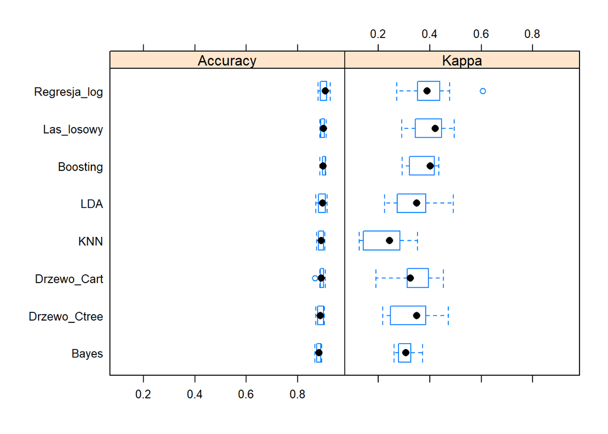

Patrząc na wartości `Accuracy` i `Kappa` możemy powiedzieć, że *Regresja logistyczna*, *Las losowy* oraz *Boosting* najlepiej poradziły sobie z zadaniem klasyfikacyjnym. Chociaż wyniki wspomnianych metod są jedynie minimalnie lepsze.

Poniżej przedstawiony zostanie rysunek wskazujący istotne różnice pomiędzy wykorzystanymi modelami klasyfikacyjnymi.

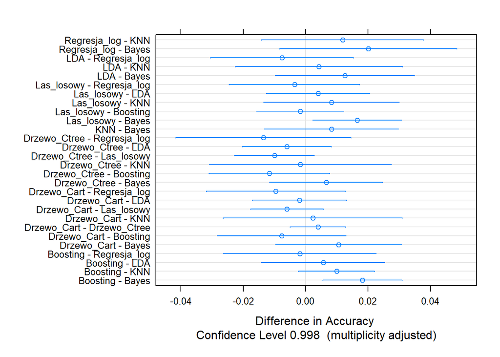

Istotne różnice otrzymujemy jednie w dwóch przypadkach, mianowicie **Las_losowy - Bayes** i **Boosting - Bayes**.

**Biorąc pod uwagę wszystkie zależności i miary dopasowania optymalnym rozwiązaniem byłoby wykorzystanie lasu losowego lub metody boosting w przedstawionym zadaniu klasyfikacyjnym.**